# Relatório 4

6 de abril de 2017

# Laboratorio 3 - checkpoint 2

### Fundamentos de Pesquisa em Ciência da Computação 2

## Discutindo os dados

O lab 3 em questão trata de agrupamentos. Os dados analisados para essa atividade foram extraídos do kaggle.com . Os mesmos tratam de um dataset com informações a respeito de filmes. Orçamento, bilheteria e números de likes no Facebook do filme são algumas de suas variáveis.

Uma limitação dos dados em questão se da pela não padronização da moeda em variáveis que utilizam tal. A moeda está de acordo com o país em que o filme foi produzido. Para evitar problemas de tal aspecto, utilizaremos em nossa análise apenas filmes produzidos nos EUA.

Ainda sobre o dataset, para analisar o agrupamento, selecionaremos as seguintes variáveis:

- Imdb_score
- Popularidade no facebook dos 3 atores principais
- Gross
- Budget
- Popularidade do filme no facebook

## Analisando os Dados em questão

Vamos agora selecionar as variáveis desejadas:

```r
movies = read_csv("dados/movie_metadata.csv")
movies = movies %>%filter(country=="USA") %>% distinct(movie_title, .keep_all = TRUE) %>% mutate(actor_likes=actor_1_facebook_likes+actor_2_facebook_likes+actor_3_facebook_likes) %>% select(movie_title, imdb_score, actor_likes, budget, movie_facebook_likes,  director_facebook_likes, gross)  %>%   mutate(budget = log10(budget), gross=log10(gross))  %>%filter(complete.cases(.))
movies = movies %>%
  mutate_at(vars(imdb_score:gross), funs(as.numeric(scale(.))))
```

Agora vamos explorar um pouco as variáveis selecionadas, por meio de seu histograma:

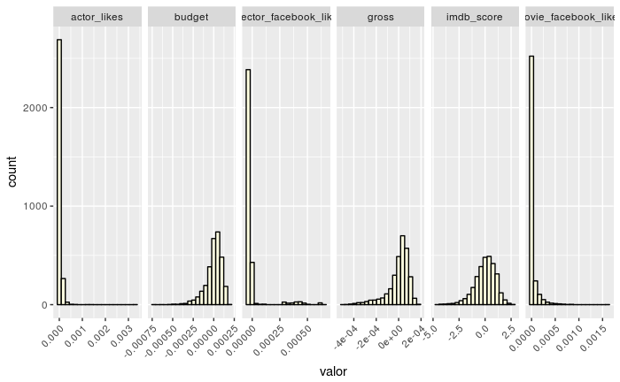

```r
movies %>%
    mutate(movie_facebook_likes = movie_facebook_likes/1e4, director_facebook_likes = director_facebook_likes/1e4,
           actor_likes = actor_likes/1e4, budget = budget/1e4, gross = gross/1e4) %>%
    gather(key = "variavel", value = "valor", -movie_title) %>%
    ggplot(aes(x = valor)) +
    theme(axis.text.x = element_text(angle = 45, hjust = 1)) +
    geom_histogram(fill = "lightyellow", color = "black", bins = 20) +
    facet_grid(. ~ variavel, scales = "free_x")
```

Analisando agora a relação entre as variáveis, vemos:

[output not shown]

[output cut: 12 more lines]

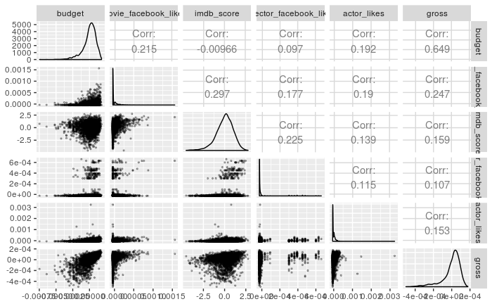

```r
movies %>%
    select(budget, movie_facebook_likes, imdb_score, director_facebook_likes, actor_likes, gross) %>%
     mutate(movie_facebook_likes = movie_facebook_likes/1e4, director_facebook_likes = director_facebook_likes/1e4,
           actor_likes = actor_likes/1e4, budget = budget/1e4, gross = gross/1e4) %>%
    ggpairs(size = .5,
            lower = list(continuous = wrap("points", size = .5, alpha = 0.3)))
```

Percebemos, em geral, uma fraca correlação entre as variáveis. A maior delas é de 0.649 entre gross e budget, que pode ser considerada média/alta. As demais são mais baixas, não passando de 0.3.

Para iniciar a procura por grupos nas variáveis estudadas, vamos analisá-las isoladamente:

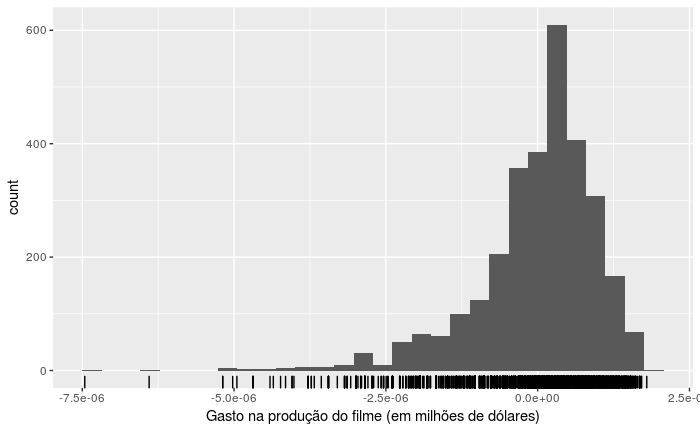

```r
movies %>%
    ggplot(aes(x = budget/1e6)) +
    labs(x='Gasto na produção do filme (em milhões de dólares)') +
    geom_histogram() +
    geom_rug()
```

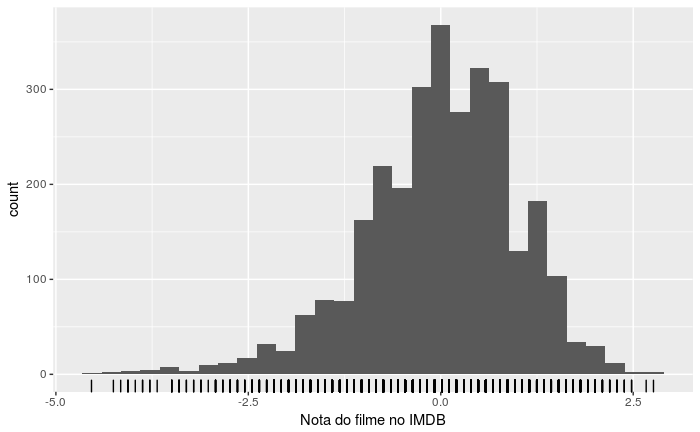

```r
movies %>%
    ggplot(aes(x = imdb_score)) +
    labs(x='Nota do filme no IMDB') +
    geom_histogram() +
    geom_rug()
```

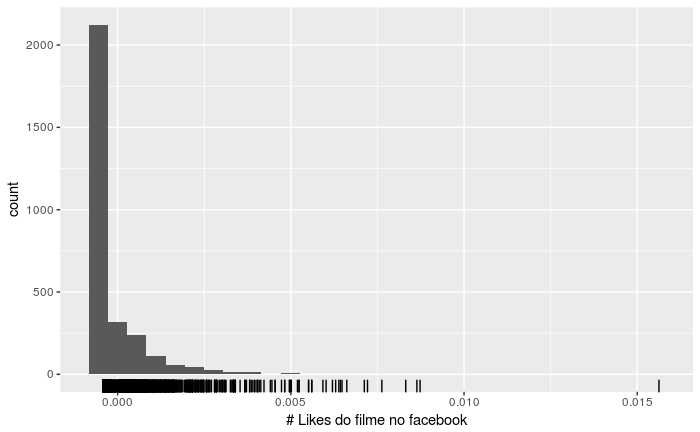

```r
movies %>%
    ggplot(aes(x = movie_facebook_likes/1e3)) +
    labs(x='# Likes do filme no facebook') +
    geom_histogram() +
    geom_rug()
```

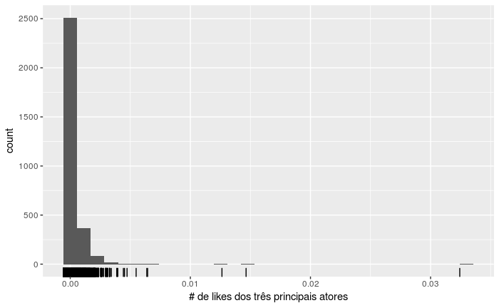

```r
movies %>%
    ggplot(aes(x = actor_likes/1e3)) +
    labs(x='# de likes dos três principais atores') +
    geom_histogram() +
    geom_rug()
```

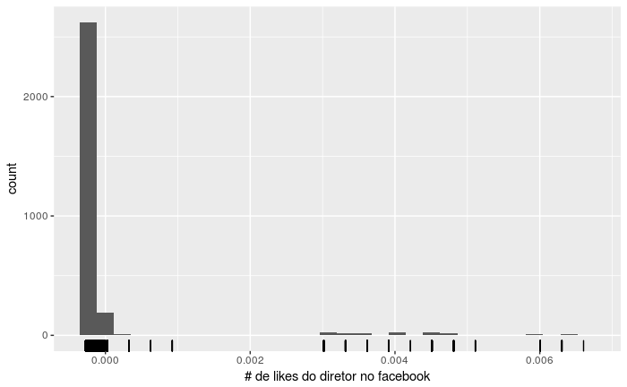

```r
movies %>%
    ggplot(aes(x = director_facebook_likes/1e3)) +
    labs(x='# de likes do diretor no facebook') +
    geom_histogram() +
    geom_rug()
```

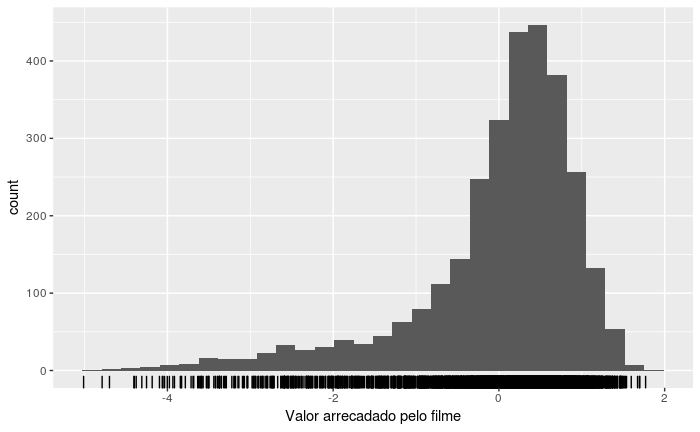

```r
movies %>%
    ggplot(aes(x = gross)) +
    labs(x='Valor arrecadado pelo filme') +
    geom_histogram() +
    geom_rug()
```

Analisando as vizualizações acima, observamos poucos padrões nas variáveis, analisando agora em ordem de grandeza(utilizando log10). Os números de likes do diretor e dos três principais atores parecem separar os dados em dois ou mais grupos.

Continuemos analisando os dados para ganhar mais confiança.

#### Utilizando, primeiramente, o HCLUST:

```r
hclust_group = movies %>%
    column_to_rownames("movie_title") %>% # hclust precisa dos rótulos em nomes de linha (ruim)
    select(budget, movie_facebook_likes, imdb_score, director_facebook_likes, gross, actor_likes) %>%
    dist(method = "euclidean") %>%
    hclust(method = "complete")
```

```
Setting row names on a tibble is deprecated.
```

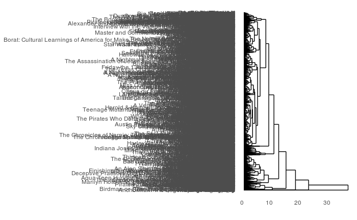

```r
ggdendrogram(hclust_group, rotate = T, size = 2)
```

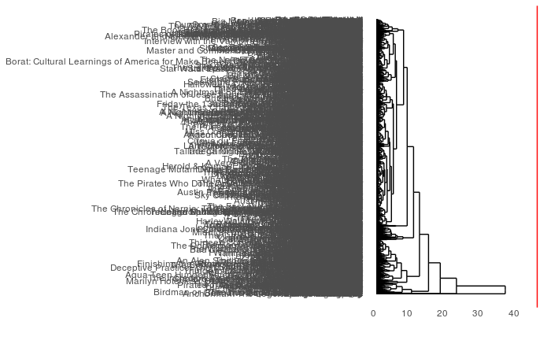

```r
ggdendrogram(hclust_group, rotate = T, size = 2) +
    geom_hline(yintercept = 45, colour = "red")
```

```r
result = tibble(k = 1:9)
different_groups = result %>%
    group_by(k) %>%
    do(cbind(movies,
             grupo = as.character(cutree(hclust_group, .$k))))
```

```
Unequal factor levels: coercing to character
```

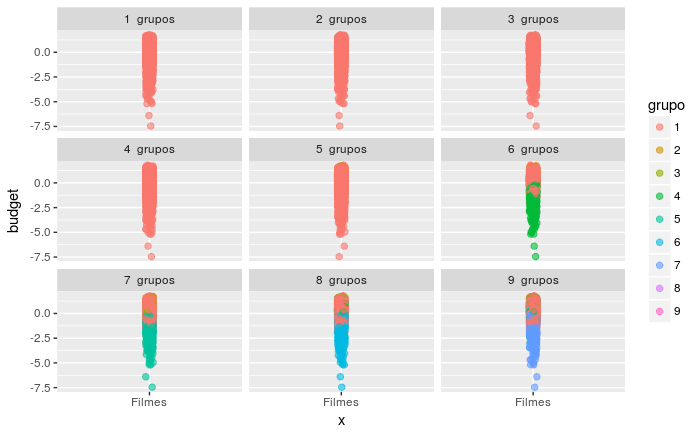

```r
different_groups %>%
    ggplot(aes(x = "Filmes", y = budget, colour = grupo)) +
    geom_jitter(width = .02, height = 0, size = 2, alpha = .6) +
    facet_wrap(~ paste(k, " grupos"))
```

```r
set.seed(123)
explorando_k = tibble(k = 3:15) %>%
    group_by(k) %>%
    do(
        kmeans(select(movies, -movie_title),
               centers = .$k,
               nstart = 20) %>% glance()
    )
```

[output not shown]

[output not shown]

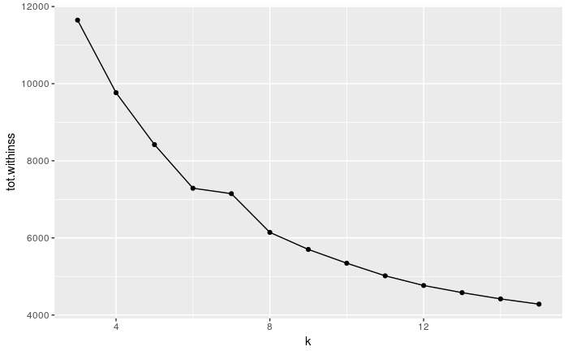

```r
explorando_k %>%
    ggplot(aes(x = k, y = tot.withinss)) +
    geom_line() +
    geom_point()
```

Combinando o resultado obtido no hclust com o gráfico acima, escolheremos um k=7 para executarmos o k-means.

```r
selected_movies = select(movies, -movie_title) %>%
    kmeans(centers = 7, nstart = 20)
```

Visualizando com coordenadas paralelas:

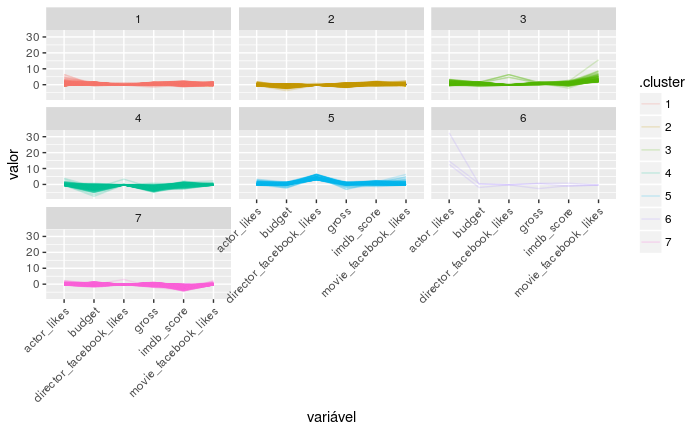

```r
selected_movies %>%
    augment(movies) %>%
    gather(key = "variável", value = "valor", -movie_title, -.cluster) %>%
    ggplot(aes(x = `variável`, y = valor, group = movie_title, colour = .cluster)) +
    theme(axis.text.x = element_text(angle = 45, hjust = 1)) +
    geom_line(alpha = .2) +
    facet_wrap(~ .cluster)
```

Analisando os grupos, por meio da visualização de coordenadas paralelas, poderíamos classificá-los assim:

-1- Filmes medianos de atores populares

-4- FIlmes medianos

-5- Filmes populares de diretores famosos

-6- Filmes de atores famosos e de votação mediana